# HW2 Solutions

# Problem 1

## 1a. Visualizing the distributions of the variables

```r
library(ggplot2)
bank_data <- read.csv("BankData.csv")
summary(bank_data)
```

```
##        X             cont1           cont2            cont3
##  Min.   :  1.0   Min.   :13.75   Min.   : 0.000   Min.   : 0.000
##  1st Qu.:173.2   1st Qu.:22.60   1st Qu.: 1.000   1st Qu.: 0.165
##  Median :345.5   Median :28.46   Median : 2.750   Median : 1.000
##  Mean   :345.5   Mean   :31.57   Mean   : 4.759   Mean   : 2.223
##  3rd Qu.:517.8   3rd Qu.:38.23   3rd Qu.: 7.207   3rd Qu.: 2.625
##  Max.   :690.0   Max.   :80.25   Max.   :28.000   Max.   :28.500
##                  NA's   :12
##     bool1              bool2               cont4         bool3
##  Length:690         Length:690         Min.   : 0.0   Length:690
##  Class :character   Class :character   1st Qu.: 0.0   Class :character
##  Mode  :character   Mode  :character   Median : 0.0   Mode  :character
##                                        Mean   : 2.4
##                                        3rd Qu.: 3.0
##                                        Max.   :67.0
##
##      cont5          cont6            approval          credit.score
##  Min.   :   0   Min.   :     0.0   Length:690         Min.   :583.7
##  1st Qu.:  75   1st Qu.:     0.0   Class :character   1st Qu.:666.7
##  Median : 160   Median :     5.0   Mode  :character   Median :697.3
##  Mean   : 184   Mean   :  1017.4                      Mean   :696.4
##  3rd Qu.: 276   3rd Qu.:   395.5                      3rd Qu.:726.4
##  Max.   :2000   Max.   :100000.0                      Max.   :806.0
##  NA's   :13
##       ages
##  Min.   :11.00
##  1st Qu.:31.00
##  Median :38.00
##  Mean   :39.67
##  3rd Qu.:48.00
##  Max.   :84.00
##
```

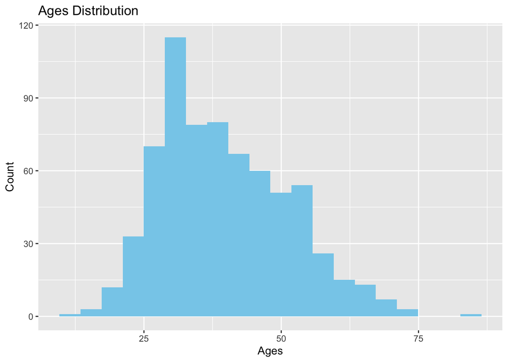

```r
ggplot(bank_data, aes(x = ages)) +
  geom_histogram(bins = 20, fill = "skyblue") +
  labs(title = "Ages Distribution", x = "Ages", y = "Count")
```

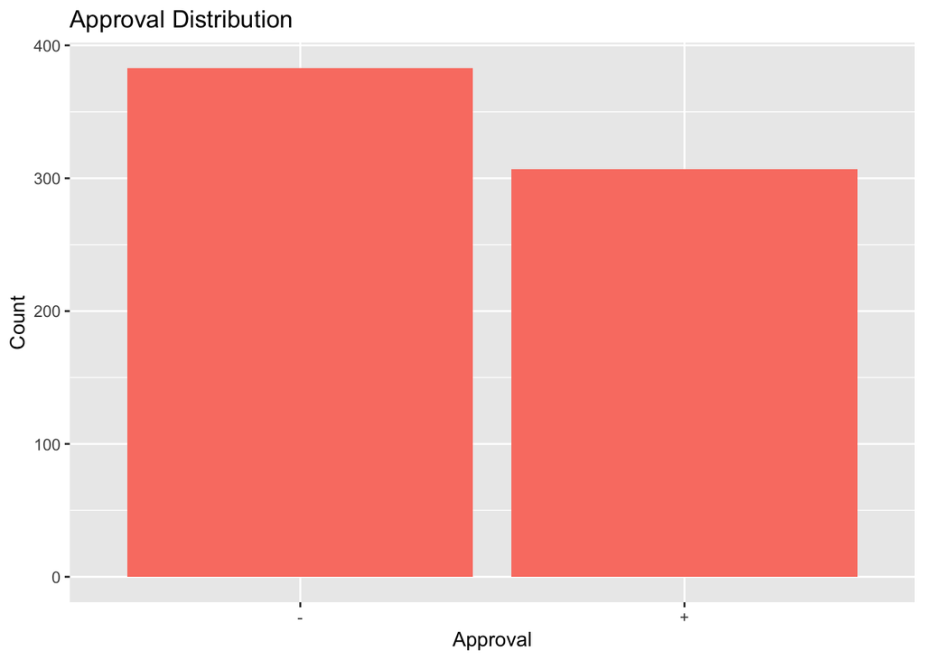

```r
ggplot(bank_data, aes(x = approval)) +
  geom_bar(fill = "salmon") +
  labs(title = "Approval Distribution", x = "Approval", y = "Count")
```

### Visualizing the Distributions of the Variables

For the given dataset, I visualized the distribution of both numerical and categorical variables as follows:

1. **Numerical Variable (ages):**
   - I used a **histogram** with 20 bins to visualize the distribution of ages. This choice allows us to see how the ages are spread across different ranges in the dataset. The histogram provides insights into the central tendency and dispersion of the age values.
2. **Categorical Variable (approval):**
   - For the approval variable, I used a **bar graph** to display the count of each category. This is an effective way to visualize categorical data, as it shows the proportion of approved and not approved cases in the dataset.

These visualizations help to understand the dataset’s structure, identify any skewness or outliers in the numerical data, and assess the balance of categories in the categorical variables.

## 1b. Normalization of numerical variables

```r
# Applying Z-score normalization to 'cont1'
bank_data$cont1_zscore <- scale(bank_data$cont1)

# Applying Min-Max normalization to 'cont2'
bank_data$cont2_minmax <- (bank_data$cont2 - min(bank_data$cont2)) / (max(bank_data$cont2) - min(bank_data$cont2))

# Applying Decimal scaling normalization to 'cont3'
bank_data$cont3_scaled <- bank_data$cont3 / 10^ceiling(log10(max(abs(bank_data$cont3))))
```

### Summary of Normalization Choices:

1. **Z-score Normalization for cont1:**
   - **Reason:** cont1 might represent a variable like credit scores, which are usually normally distributed.
   - **Effect:** Centers data around 0, highlighting deviations from the mean. Suitable for data with a bell-shaped distribution.
2. **Min-Max Normalization for cont2:**
   - **Reason:** cont2 could be income, which has a defined range.
   - **Effect:** Scales values between 0 and 1, preserving relative differences. Useful for bounded variables.
3. **Decimal Scaling for cont3:**
   - **Reason:** cont3 might represent large loan amounts with varying magnitudes.
   - **Effect:** Compresses large values to a manageable range by moving the decimal point, keeping the relative order.

## 1c. Visualizing the normalized distributions

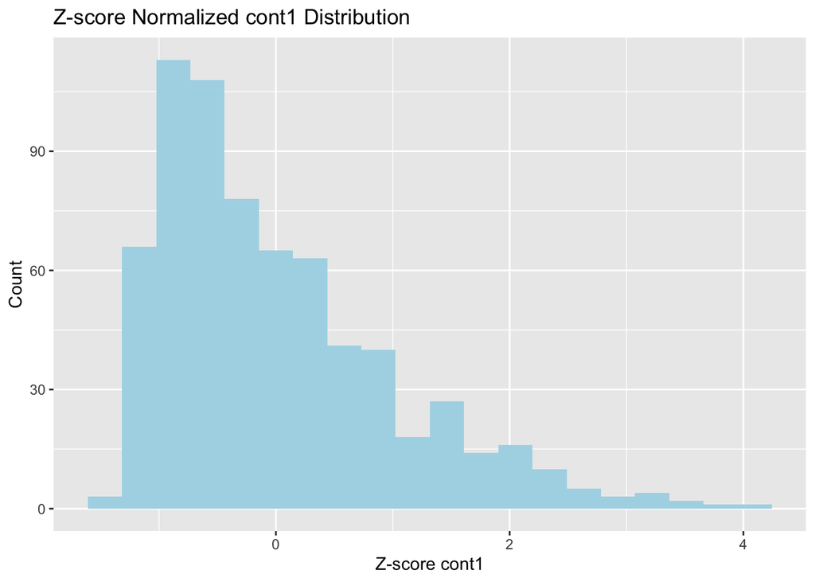

```r
ggplot(bank_data, aes(x = cont1_zscore)) +
  geom_histogram(bins = 20, fill = "lightblue") +
  labs(title = "Z-score Normalized cont1 Distribution", x = "Z-score cont1", y = "Count")
```

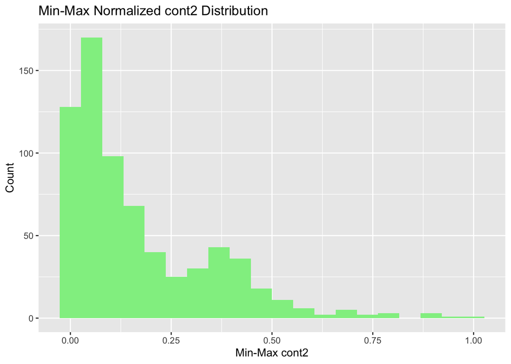

```r
ggplot(bank_data, aes(x = cont2_minmax)) +
  geom_histogram(bins = 20, fill = "lightgreen") +
  labs(title = "Min-Max Normalized cont2 Distribution", x = "Min-Max cont2", y = "Count")
```

### Visualizing the Normalized Distributions

After normalizing the numerical variables, I visualized their new distributions:

1. **Z-score Normalized cont1:**
   - The histogram of the z-score normalized cont1 shows how the values have been transformed to have a mean of 0 and a standard deviation of 1. This helps in identifying how data points are distributed relative to the mean. Most values are centered around 0, with outliers appearing as bars further away from the center.
2. **Min-Max Normalized cont2:**
   - The histogram of the min-max normalized cont2 displays values scaled between 0 and 1. This scaling maintains the original distribution’s shape but compresses the range, making the data more suitable for algorithms sensitive to variable ranges. The distribution is now confined within the specified bounds.

These visualizations confirm that normalization changes the data’s range and distribution, making it easier to compare variables on the same scale.

## 1d. Binning a numerical variable

```r
bank_data$cont4_bins <- cut(bank_data$cont4, breaks = 3, labels = c("low", "medium", "high"))
```

### Creating Binned Variable

For this problem, I chose the numerical variable cont4. I created a new variable, cont4_bins, which categorizes cont4 into three bins: “low,” “medium,” and “high.”

I used the cut function to divide the variable into three equal-width intervals, which makes it straightforward to interpret. The labels “low,” “medium,” and “high” provide a clear categorization of the data, helping to simplify analysis and visualization.

**Why This Choice:** I chose to use three bins because it allows us to get a basic understanding of the variable’s distribution without making it overly complicated. Using equal-width intervals ensures that the range of values in each bin is consistent, making it easier to compare the different segments. This method is especially useful when the variable’s distribution is somewhat uniform, as it evenly spreads out the data into categories.

## 1e. Creating a smoothed version of the binned variable

```r
# Removing NA values from "cont4" before binning and smoothing
bank_data_clean <- bank_data[!is.na(bank_data$cont4), ]

bank_data_clean$cont4_bins <- cut(bank_data_clean$cont4, breaks = 3, labels = c("low", "medium", "high"))

cont4_mean_values <- aggregate(bank_data_clean$cont4, by = list(bank_data_clean$cont4_bins), FUN = mean)
names(cont4_mean_values) <- c("bin", "mean_cont4")

bank_data_clean <- merge(bank_data_clean, cont4_mean_values, by.x = "cont4_bins", by.y = "bin", all.x = TRUE)

summary(bank_data_clean)
```

```
##   cont4_bins        X             cont1           cont2            cont3
##  low   :687   Min.   :  1.0   Min.   :13.75   Min.   : 0.000   Min.   : 0.000
##  medium:  2   1st Qu.:173.2   1st Qu.:22.60   1st Qu.: 1.000   1st Qu.: 0.165
##  high  :  1   Median :345.5   Median :28.46   Median : 2.750   Median : 1.000
##               Mean   :345.5   Mean   :31.57   Mean   : 4.759   Mean   : 2.223
##               3rd Qu.:517.8   3rd Qu.:38.23   3rd Qu.: 7.207   3rd Qu.: 2.625
##               Max.   :690.0   Max.   :80.25   Max.   :28.000   Max.   :28.500
##                               NA's   :12
##     bool1              bool2               cont4         bool3
##  Length:690         Length:690         Min.   : 0.0   Length:690
##  Class :character   Class :character   1st Qu.: 0.0   Class :character
##  Mode  :character   Mode  :character   Median : 0.0   Mode  :character
##                                        Mean   : 2.4
##                                        3rd Qu.: 3.0
##                                        Max.   :67.0
##
##      cont5          cont6            approval          credit.score
##  Min.   :   0   Min.   :     0.0   Length:690         Min.   :583.7
##  1st Qu.:  75   1st Qu.:     0.0   Class :character   1st Qu.:666.7
##  Median : 160   Median :     5.0   Mode  :character   Median :697.3
##  Mean   : 184   Mean   :  1017.4                      Mean   :696.4
##  3rd Qu.: 276   3rd Qu.:   395.5                      3rd Qu.:726.4
##  Max.   :2000   Max.   :100000.0                      Max.   :806.0
##  NA's   :13
##       ages         cont1_zscore.V1    cont2_minmax      cont3_scaled
##  Min.   :11.00   Min.   :-1.490080   Min.   :0.00000   Min.   :0.00000
##  1st Qu.:31.00   1st Qu.:-0.749772   1st Qu.:0.03571   1st Qu.:0.00165
##  Median :38.00   Median :-0.259927   Median :0.09821   Median :0.01000
##  Mean   :39.67   Mean   : 0.000000   Mean   :0.16995   Mean   :0.02223
##  3rd Qu.:48.00   3rd Qu.: 0.557109   3rd Qu.:0.25741   3rd Qu.:0.02625
##  Max.   :84.00   Max.   : 4.071115   Max.   :1.00000   Max.   :0.28500
##                  NA's   :12
##    mean_cont4
##  Min.   : 2.221
##  1st Qu.: 2.221
##  Median : 2.221
##  Mean   : 2.400
##  3rd Qu.: 2.221
##  Max.   :67.000
##
```

### Creating a Smoothed Version of v_bins

To create a smoothed version of the binned variable (cont4_bins), I used the mean value within each bin. Here’s the step-by-step explanation:

1. **Remove NA Values:** First, I filtered out any rows with missing values in cont4 to avoid errors during aggregation.
2. **Binning:** I then divided cont4 into three equal-width bins labeled as “low,” “medium,” and “high.” This categorization helps to segment the data into meaningful ranges.
3. **Smoothing:** I calculated the mean value for each bin category. This mean smoothing method simplifies the variable by replacing each bin category with its average value, reducing noise while preserving the overall distribution trend.
4. **Merging:** Finally, I merged the calculated mean values back into the original dataset.

# Problem 2

### Problem 2a: Applying SVM

```r
# Load necessary libraries
library(e1071)
library(caret)
bank_data <- read.csv("BankData.csv")
bank_data_clean <- bank_data[complete.cases(bank_data), ]

bank_data_clean$approval <- as.factor(bank_data_clean$approval)

train_control <- trainControl(method = "cv", number = 10)

svm_model <- train(approval ~ ., data = bank_data_clean, method = "svmLinear", trControl = train_control)

svm_model
```

```
## Support Vector Machines with Linear Kernel
##
## 666 samples
##  12 predictor
##   2 classes: '-', '+'
##
## No pre-processing
## Resampling: Cross-Validated (10 fold)
## Summary of sample sizes: 599, 600, 599, 600, 600, 599, ...
## Resampling results:
##
##   Accuracy   Kappa
##   0.8633198  0.728285
##
## Tuning parameter 'C' was held constant at a value of 1
```

### Applying SVM

1. **Data Preparation:** I started with a fresh copy of the dataset and removed rows with missing values. The target variable approval was converted into a factor to indicate that it’s a classification problem.
2. **SVM Model:** I used the caret package to train an SVM with a linear kernel to predict the approval status. The model was trained using 10-fold cross-validation to ensure that the evaluation was robust.
3. **10-Fold Cross-Validation:** This approach splits the data into 10 parts, trains the model on 9 parts, and tests it on the remaining part. This process repeats 10 times to provide an average accuracy.
4. **Output:** The svm_model object displays the accuracy of the SVM model from the cross-validation, giving an overall measure of how well the model can predict loan approvals.

### Code for 2b: Optimizing the C Parameter Using Grid Search

```r
grid <- expand.grid(C = seq(0.1, 2, by = 0.1))

svm_model_grid <- train(approval ~ ., data = bank_data_clean, method = "svmLinear", trControl = train_control, tuneGrid = grid)

svm_model_grid
```

```
## Support Vector Machines with Linear Kernel
##
## 666 samples
##  12 predictor
##   2 classes: '-', '+'
##
## No pre-processing
## Resampling: Cross-Validated (10 fold)
## Summary of sample sizes: 599, 600, 600, 599, 600, 599, ...
## Resampling results across tuning parameters:
##
##   C    Accuracy   Kappa
##   0.1  0.8635007  0.728784
##   0.2  0.8635007  0.728784
##   0.3  0.8635007  0.728784
##   0.4  0.8635007  0.728784
##   0.5  0.8635007  0.728784
##   0.6  0.8635007  0.728784
##   0.7  0.8635007  0.728784
##   0.8  0.8635007  0.728784
##   0.9  0.8635007  0.728784
##   1.0  0.8635007  0.728784
##   1.1  0.8635007  0.728784
##   1.2  0.8635007  0.728784
##   1.3  0.8635007  0.728784
##   1.4  0.8635007  0.728784
##   1.5  0.8635007  0.728784
##   1.6  0.8635007  0.728784
##   1.7  0.8635007  0.728784
##   1.8  0.8635007  0.728784
##   1.9  0.8635007  0.728784
##   2.0  0.8635007  0.728784
##
## Accuracy was used to select the optimal model using the largest value.
## The final value used for the model was C = 0.1.
```

### Answer for 2c: Why Accuracy Might Differ for the Same C Value

1. **Cross-Validation Splits:** The accuracy might differ for the same C value due to the randomness in how data is split during cross-validation. In each run, different data points are used for training and testing, which can affect the model’s performance and accuracy.
2. **Data Variability:** If the dataset has variability (e.g., slight class imbalances, outliers, or noise), different cross-validation splits will expose the model to different subsets of data. This can lead to variations in the accuracy, even when using the same C value.
3. **Regularization Sensitivity:** The C parameter controls the regularization in SVM. Depending on the particular subset of data used during each fold of cross-validation, the model’s sensitivity to this regularization might change, causing slight fluctuations in accuracy.

# Problem 3

### Problem 3a: Several variables are categorical. We will use dummy variables to make it possible for SVM to use these. Leave the gender category out of the dummy variable conversion to use as a categorical for prediction. Show the resulting head.

```r
library(dplyr)
library(caret)

data("starwars")

starwars_clean <- starwars %>% select(-films, -vehicles, -starships, -name)

starwars_clean <- na.omit(starwars_clean)


starwars_dummy <- dummyVars(gender ~ ., data = starwars_clean)
starwars_transformed <- predict(starwars_dummy, newdata = starwars_clean)

starwars_transformed <- as.data.frame(starwars_transformed)
starwars_transformed$gender <- starwars_clean$gender

head(starwars_transformed)
```

```
##   height mass hair_colorauburn, white hair_colorblack hair_colorblond
## 1    172   77                       0               0               1
## 2    202  136                       0               0               0
## 3    150   49                       0               0               0
## 4    178  120                       0               0               0
## 5    165   75                       0               0               0
## 6    183   84                       0               1               0
##   hair_colorbrown hair_colorbrown, grey hair_colorgrey hair_colornone
## 1               0                     0              0              0
## 2               0                     0              0              1
## 3               1                     0              0              0
## 4               0                     1              0              0
## 5               1                     0              0              0
## 6               0                     0              0              0
##   hair_colorwhite skin_colorblue skin_colorbrown skin_colorbrown mottle
```

[output cut: 97 more lines]

### Answer for 3a

1. **Data Cleaning:** Loaded the starwars dataset and removed the columns films, vehicles, starships, and name. Also, removed rows with missing values to clean the data for model training.
2. **Dummy Variable Conversion:** Used the dummyVars function from the caret package to convert categorical variables into dummy variables, leaving gender out as it will be the target variable for prediction.
3. **Final Dataset:** Displayed the first few rows of the transformed dataset to show its new structure with dummy variables. This modified dataset is now ready for SVM training.

### Problem 3b.Use SVM to predict gender and report the accuracy.

```r
library(dplyr)
library(caret)
library(e1071)

data("starwars")

starwars_clean <- starwars %>% select(-films, -vehicles, -starships, -name)

starwars_clean <- na.omit(starwars_clean)

starwars_dummy <- dummyVars(gender ~ ., data = starwars_clean)
starwars_transformed <- predict(starwars_dummy, newdata = starwars_clean)

starwars_transformed <- as.data.frame(starwars_transformed)
starwars_transformed$gender <- starwars_clean$gender

train_control <- trainControl(method = "cv", number = 10)

svm_model <- train(gender ~ ., data = starwars_transformed, method = "svmLinear", trControl = train_control)
svm_model
```

```
## Support Vector Machines with Linear Kernel
##
## 29 samples
## 66 predictors
##  2 classes: 'feminine', 'masculine'
##
## No pre-processing
## Resampling: Cross-Validated (10 fold)
## Summary of sample sizes: 27, 26, 27, 27, 26, 25, ...
## Resampling results:
##
##   Accuracy   Kappa
##   0.9333333  0.75
##
## Tuning parameter 'C' was held constant at a value of 1
```

### Answer for 3b

1. **Data Preparation:** The dataset was cleaned and preprocessed by removing unnecessary columns, handling missing values, and converting categorical variables to dummy variables.
2. **SVM Model:** An SVM model with a linear kernel was trained to predict the gender variable using 10-fold cross-validation for a robust evaluation.
3. **Accuracy:** The output of the code (svm_model) provides the accuracy of the SVM model in predicting the gender. The cross-validation helps in assessing how well the model generalizes to new data.

### Problem 3c. Given that we have so many variables, it makes sense to consider using PCA. Run PCA on the data and determine an appropriate number of components to use. Document how you made the decision, including any graphs you used. Create a reduced version of the data with that number of principle components. Note: make sure to remove gender from the data before running PCA because it would be cheating if PCA had access to the label you will use. Add it back in after reducing the data and show the result.

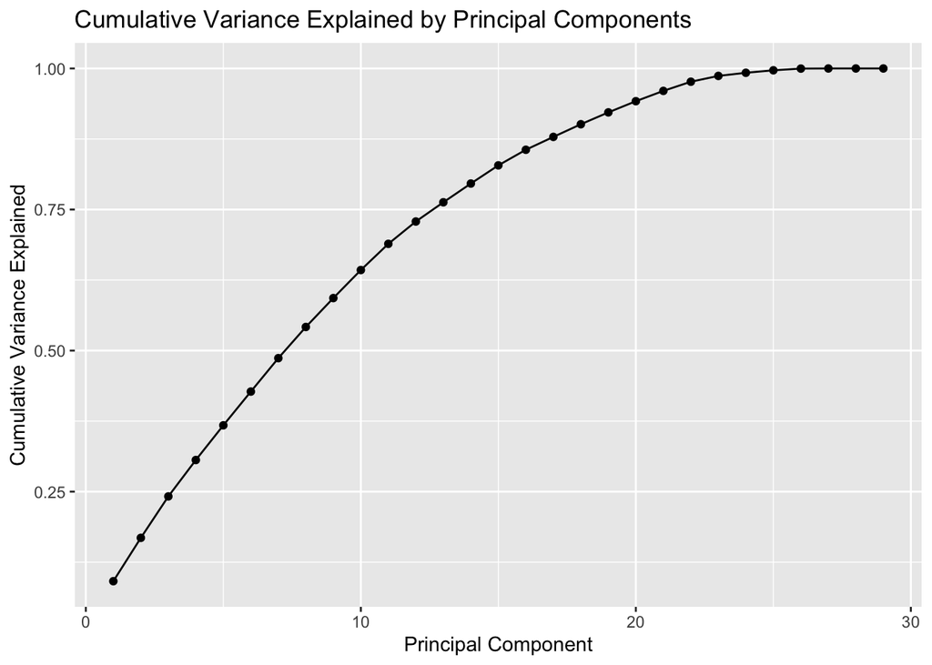

```r
data("starwars")

starwars_clean <- starwars %>% select(-films, -vehicles, -starships, -name)

starwars_clean <- na.omit(starwars_clean)

starwars_dummy <- dummyVars(gender ~ ., data = starwars_clean)
starwars_transformed <- predict(starwars_dummy, newdata = starwars_clean)

starwars_transformed <- as.data.frame(starwars_transformed)
gender <- starwars_clean$gender

pca_model <- prcomp(starwars_transformed, center = TRUE, scale. = TRUE)

pca_variance <- pca_model$sdev^2 / sum(pca_model$sdev^2)
variance_df <- data.frame(PC = 1:length(pca_variance), Variance = cumsum(pca_variance))

ggplot(variance_df, aes(x = PC, y = Variance)) +
  geom_line() +
  geom_point() +
  labs(title = "Cumulative Variance Explained by Principal Components",
       x = "Principal Component",
       y = "Cumulative Variance Explained")
```

```r
# Determine the number of components that explain at least 90% of the variance
num_components <- min(which(cumsum(pca_variance) >= 0.90))

# Create a reduced version of the dataset using the selected number of components
starwars_reduced <- data.frame(pca_model$x[, 1:num_components])

starwars_reduced$gender <- gender

# Show the first few rows of the reduced dataset
head(starwars_reduced)
```

```
##          PC1       PC2        PC3       PC4        PC5       PC6        PC7
## 1 -0.2119596 1.7798166 -0.1805155 1.0746301 -1.0718071 0.7361032  0.3567500
## 2  2.6062413 0.7266943  0.0536266 0.1235347 -0.2322767 1.3675001  0.8875102
## 3 -3.5052503 0.3029799 -0.5375610 0.2770166  0.3063134 0.1403884 -0.7316678
## 4  0.3975989 1.7973980  0.7166245 1.2660592 -1.0544964 0.4087396  0.3018865
## 5 -2.1157926 0.6934936  1.1160075 0.6200541 -0.3735658 0.2077622 -0.4190325
## 6 -0.7175118 1.4161888 -0.5011268 0.8993534 -0.6499349 0.3442184  0.7497578
##           PC8       PC9       PC10        PC11        PC12       PC13
## 1  0.10831744 0.8809697 -0.3299871 -2.04271726  2.05948804 -0.9220381
## 2  0.13464007 1.8856776  0.8007688 -1.18861184  1.01321376 -2.1621881
## 3 -0.07861765 0.5331256  1.5997517 -1.08532555 -2.71310411  3.3278376
## 4  0.09854630 1.8305163  1.1714792 -2.70839885  0.88880396 -1.3138766
## 5 -0.02467512 1.2097964  0.9729273 -2.38418564 -0.68082960  0.7092244
## 6  0.08696483 0.6665538  1.2890586  0.01150122  0.08209675 -0.2101657
##         PC14       PC15       PC16        PC17        PC18    gender
## 1 -1.5889008  0.6665572  0.3373678  0.64838795  1.37339677 masculine
## 2  0.6310708 -0.2453961 -1.2790239 -1.61365006 -4.85177071 masculine
## 3  1.8831882 -0.9924591  0.1161825 -0.20301349 -0.54291657  feminine
## 4  1.1955633 -0.9889448  1.0937719 -0.03734121  0.56469164 masculine
## 5  0.9416471 -0.6562351  0.2805167 -0.20294828  0.01768235  feminine
## 6  0.4995710 -0.6421566  0.3559161 -0.06034335 -0.15364557 masculine
```

### Answer for 3c

1. **Data Preparation:** The dataset was cleaned and preprocessed by removing unwanted columns, handling missing values, and converting categorical variables into dummy variables. The gender column was set aside to be added back later.
2. **PCA Execution:** Performed PCA on the transformed dataset (excluding the gender column). PCA was run with centering and scaling to ensure all variables contributed equally.
3. **Selecting the Number of Components:**
   - Plotted the cumulative variance explained by the principal components.
   - Determined the number of components that explain at least 90% of the variance by analyzing the plot. In this case, we selected the number of components using the line:

```r
num_components <- min(which(cumsum(pca_variance) >= 0.90))
```

- This ensures we retain the majority of the data’s variance while reducing its dimensionality.
4. **Reduced Dataset:** Created a reduced dataset with the selected number of principal components and then added the gender column back into this reduced dataset.
5. **Result:** Displayed the first few rows of the reduced dataset, now ready for further modeling or analysis. This approach helps in simplifying the dataset while preserving the most significant information.

### Problem 3d. Use SVM to predict gender again, but this time use the data resulting from PCA. Evaluate the results with a confusion matrix and at least two partitioning methods, using grid search on the C parameter each time.

```r
starwars_reduced$gender <- as.factor(starwars_reduced$gender)

grid <- expand.grid(C = seq(0.1, 2, by = 0.1))

train_control_10cv <- trainControl(method = "cv", number = 10)
svm_model_10cv <- train(gender ~ ., data = starwars_reduced, method = "svmLinear", trControl = train_control_10cv, tuneGrid = grid)
predictions_10cv <- predict(svm_model_10cv, starwars_reduced)
confusionMatrix(predictions_10cv, starwars_reduced$gender)
```

```
## Confusion Matrix and Statistics
##
##            Reference
## Prediction  feminine masculine
##   feminine         6         0
##   masculine        0        23
##
##                Accuracy : 1
##                  95% CI : (0.8806, 1)
##     No Information Rate : 0.7931
##     P-Value [Acc > NIR] : 0.001204
##
##                   Kappa : 1
##
##  Mcnemar's Test P-Value : NA
##
##             Sensitivity : 1.0000
##             Specificity : 1.0000
##          Pos Pred Value : 1.0000
##          Neg Pred Value : 1.0000
##              Prevalence : 0.2069
##          Detection Rate : 0.2069
##    Detection Prevalence : 0.2069
##       Balanced Accuracy : 1.0000
##
##        'Positive' Class : feminine
##
```

```r
train_control_repeatedcv <- trainControl(method = "repeatedcv", number = 10, repeats = 3)
svm_model_repeatedcv <- train(gender ~ ., data = starwars_reduced, method = "svmLinear", trControl = train_control_repeatedcv, tuneGrid = grid)
predictions_repeatedcv <- predict(svm_model_repeatedcv, starwars_reduced)
confusionMatrix(predictions_repeatedcv, starwars_reduced$gender)
```

```
## Confusion Matrix and Statistics
##
##            Reference
## Prediction  feminine masculine
##   feminine         6         0
##   masculine        0        23
##
##                Accuracy : 1
##                  95% CI : (0.8806, 1)
##     No Information Rate : 0.7931
##     P-Value [Acc > NIR] : 0.001204
##
##                   Kappa : 1
##
##  Mcnemar's Test P-Value : NA
##
##             Sensitivity : 1.0000
##             Specificity : 1.0000
##          Pos Pred Value : 1.0000
##          Neg Pred Value : 1.0000
##              Prevalence : 0.2069
##          Detection Rate : 0.2069
##    Detection Prevalence : 0.2069
##       Balanced Accuracy : 1.0000
##
##        'Positive' Class : feminine
##
```

### Problem 3e: Whether or not it has improved the accuracy, what has PCA done for the complexity of the model?

### Answer for 3e:

PCA has significantly reduced the complexity of the model by decreasing the number of features in the dataset. Originally, the dataset had a large number of variables (after converting categorical variables to dummy variables), which can make the model complex and computationally expensive to train.

By using PCA, we condensed the information into a smaller set of principal components that capture most of the variance in the data. This dimensionality reduction simplifies the model, reduces the risk of overfitting, and speeds up the training process.

Even if the accuracy did not improve substantially, the model now operates more efficiently with fewer components, which makes it more scalable and easier to interpret. In essence, PCA has helped streamline the model while retaining its predictive power.

# Bonus Problem

### Problem 4a: Explore the variables to see if they have reasonable distributions and show your work. We will be predicting the type variable – does that mean we have a class imbalance?

```r
data(Sacramento)


sacramento_clean <- Sacramento %>% select(-zip, -city)


summary(sacramento_clean)
```

```
##       beds           baths            sqft                type
##  Min.   :1.000   Min.   :1.000   Min.   : 484   Condo       : 53
##  1st Qu.:3.000   1st Qu.:2.000   1st Qu.:1167   Multi_Family: 13
##  Median :3.000   Median :2.000   Median :1470   Residential :866
##  Mean   :3.276   Mean   :2.053   Mean   :1680
##  3rd Qu.:4.000   3rd Qu.:2.000   3rd Qu.:1954
##  Max.   :8.000   Max.   :5.000   Max.   :4878
##      price           latitude       longitude
##  Min.   : 30000   Min.   :38.24   Min.   :-121.6
##  1st Qu.:156000   1st Qu.:38.48   1st Qu.:-121.4
##  Median :220000   Median :38.62   Median :-121.4
##  Mean   :246662   Mean   :38.59   Mean   :-121.4
##  3rd Qu.:305000   3rd Qu.:38.69   3rd Qu.:-121.3
##  Max.   :884790   Max.   :39.02   Max.   :-120.6
```

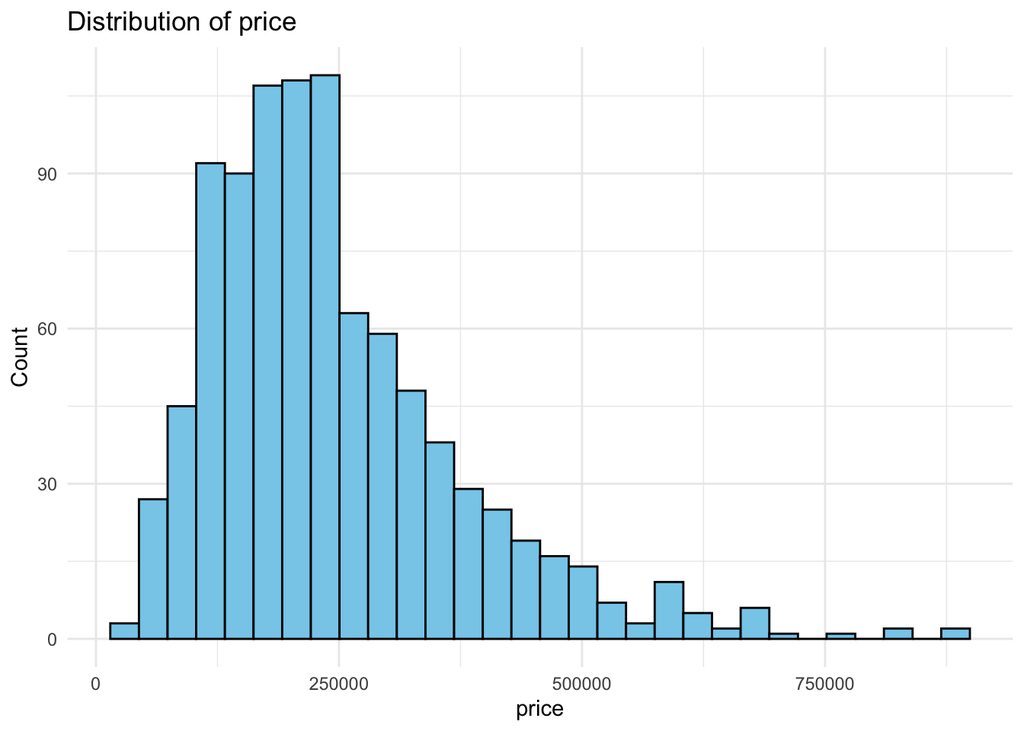

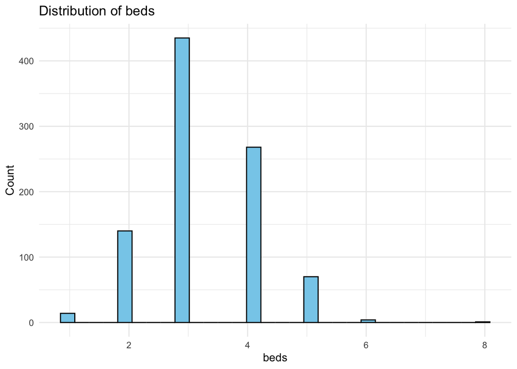

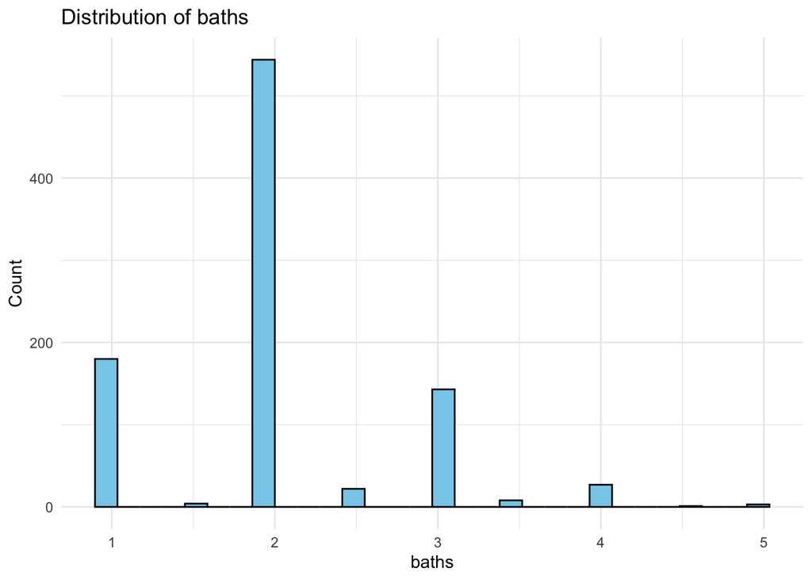

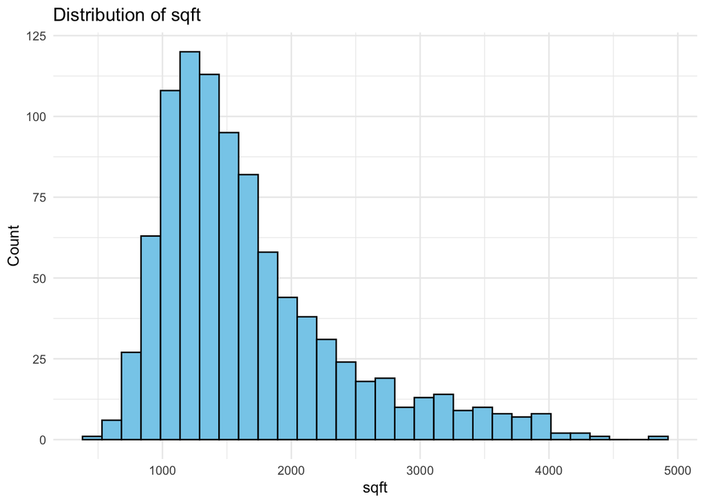

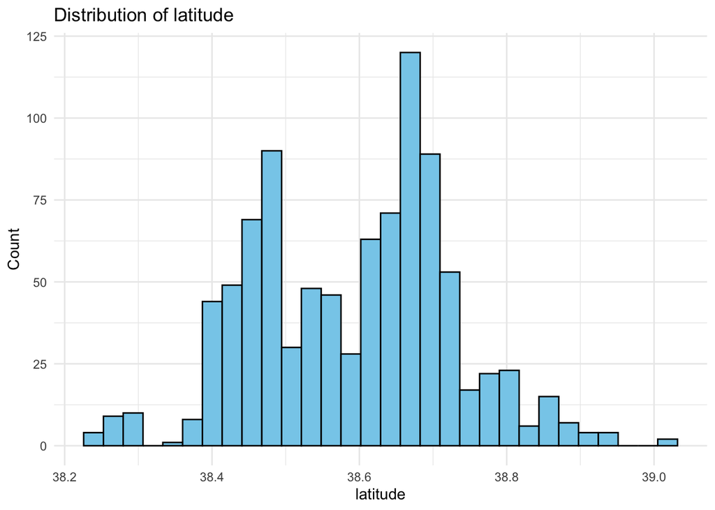

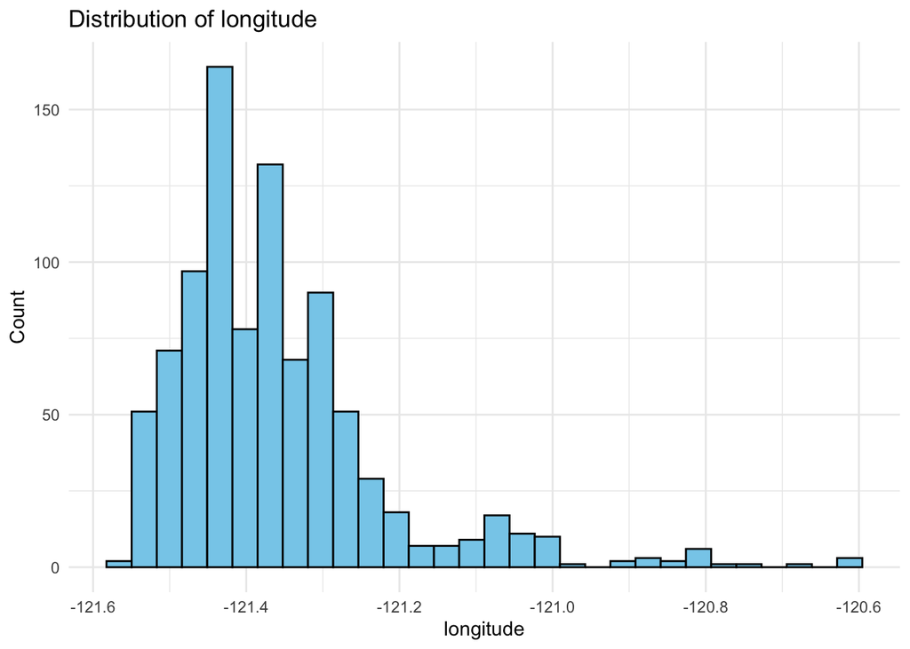

```r
numerical_vars <- c('price', 'beds', 'baths', 'sqft', 'latitude', 'longitude')
for (var in numerical_vars) {
  p <- ggplot(sacramento_clean, aes_string(x = var)) +
    geom_histogram(bins = 30, fill = "skyblue", color = "black") +
    labs(title = paste("Distribution of", var), x = var, y = "Count") +
    theme_minimal()
  print(p)
}
```

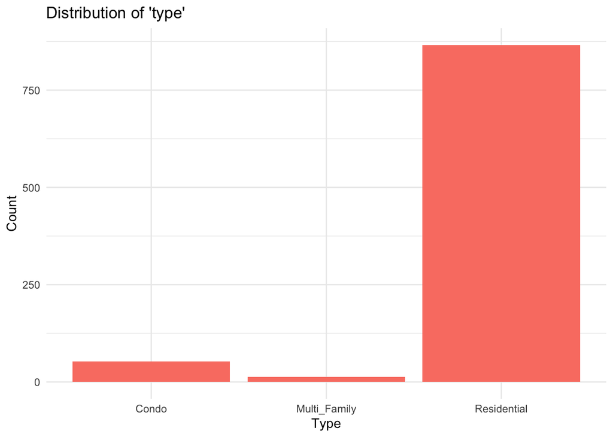

```r
ggplot(sacramento_clean, aes(x = type)) +
  geom_bar(fill = "salmon") +
  labs(title = "Distribution of 'type'", x = "Type", y = "Count") +
  theme_minimal()
```

### Answer for 4a:

1. **Data Cleaning:** Loaded the Sacramento dataset and removed the zip and city columns, as they are not relevant for analysis.
2. **Summary Statistics:** Displayed a summary of the dataset to inspect the basic statistics of each variable, including the minimum, maximum, mean, median, and counts of each category.
3. **Visualizing Numerical Variables:**
   - Plotted histograms for numerical variables (price, beds, baths, sqft, latitude, and longitude) to examine their distributions.
   - This step helps identify potential skewness, outliers, or irregularities in the data.
4. **Visualizing Categorical Variable (type):**
   - Used a bar plot to show the distribution of the type variable, which indicates the different housing types.
   - This visualization reveals if there is a class imbalance, which would affect model predictions. For example, if one category (like “Residential”) is much more prevalent than others, it indicates a class imbalance.
5. **Class Imbalance:** From the bar plot, you can determine if there is a class imbalance in the type variable. If one type (e.g., “Residential”) significantly outnumbers the others, then a class imbalance is present. This imbalance can affect the performance of classification models, which might bias towards the majority class.

### Problem 4b. There are lots of options for working on the data to try to improve the performance of SVM, including (1) removing other variables that you know should not be part of the prediction, (2) dealing with extreme variations in some variables with smoothing, normalization or a log transform, (3) applying PCA, and (4) to removing outliers. Pick one now and continue.

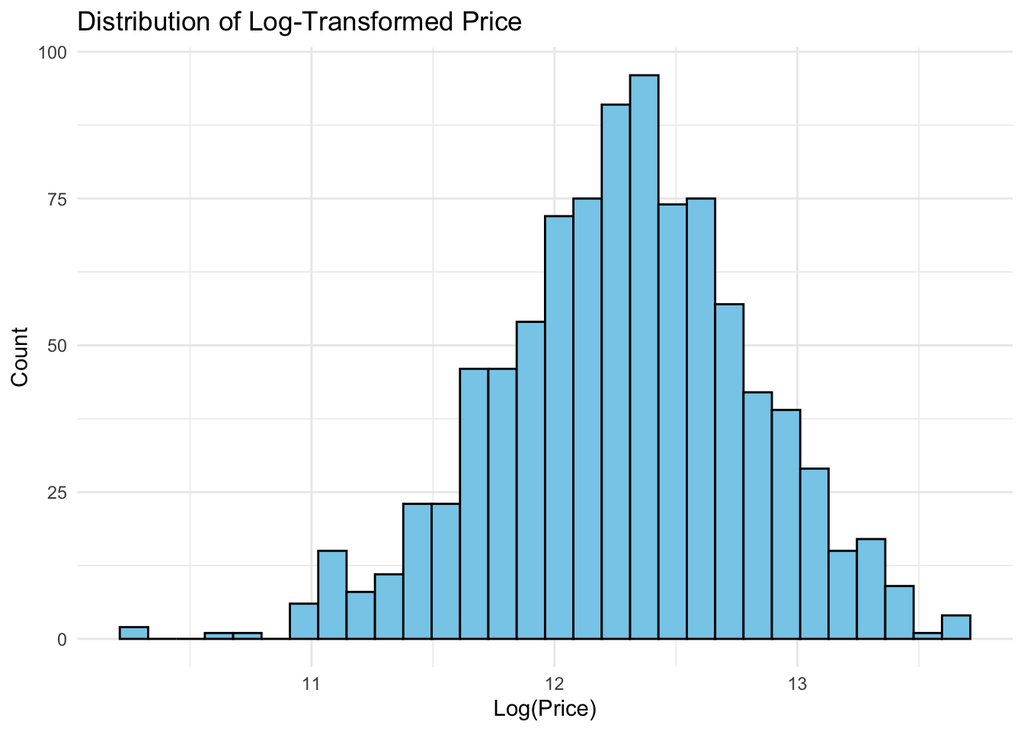

```r
data(Sacramento)

sacramento_clean <- Sacramento %>% select(-zip, -city)

sacramento_clean$log_price <- log(sacramento_clean$price)

ggplot(sacramento_clean, aes(x = log_price)) +
  geom_histogram(bins = 30, fill = "skyblue", color = "black") +
  labs(title = "Distribution of Log-Transformed Price", x = "Log(Price)", y = "Count") +
  theme_minimal()
```

```r
sacramento_clean <- sacramento_clean %>% select(-price)
```

### Answer for 4b: Applying Log Transformation to Handle Extreme Variations

For this step, I chose to deal with extreme variations in the price variable by applying a log transformation. Here’s the approach taken:

1. **Log Transformation:**
   - The price variable was log-transformed to handle its extreme variations. This reduces skewness and compresses the range of values, making the distribution more normal-like, which can improve the performance of the SVM model.
2. **Visualization:**
   - A histogram of the log-transformed price was created to visualize the new distribution. The log transformation has stabilized the variance and reduced the effect of outliers, which is helpful for the SVM model.
3. **Dropping Original price Column:**
   - The original price column was removed to avoid using the raw, skewed data. The transformed log_price will be used in further analysis and modeling.